# Reference construction Gafftops

```r
knitr::opts_chunk$set(warning = FALSE, message = FALSE)

# # initiate git repository
# system('git config --global user.email "shannon.j.oleary@gmail.com"')
# system('git config --global user.name "shannon"')

source("scr/libraries.R")
library(glue)

source("scr/ggplot.R")
source("scr/xtrafunctions.R")
```

# Identify individuals to use for reference assembly

Import `radtagslog` file which contains the number of reads per individual.

```r
radtagslog <- read_delim("results/all.radtags.log", delim = " ")
```

Per library identify top 10 individuals with highest number of reads.

```r
ref_ind <- radtagslog %>%
  group_by(LIBRARY) %>%
  top_n(10, wt = RETAINED) %>%
  ungroup()
```

Create folder for reference individuals.

```bash
mkdir /home/soleary/GAFFTOPS/BMA_POPGEN/data/REF/REF_IND
```

Write bash script to copy `fastq` files of reference individuals from BMA1 into a single directory.

```r
path <- "/home/soleary/GAFFTOPS/BMA_POPGEN/data/REF/REF_IND/"
seq_dir <- "/home/soleary/GAFFTOPS/BMA_POPGEN/data/SEQ/BMA-1/"
command <- "cp"
SEQ <- ref_ind %>%
  filter(LIBRARY == "BMA1") %>%
  select(SAMPLE) %>%
  mutate(temp = ".*",
         dir = seq_dir) %>%
  unite(SEQ, dir, SAMPLE, temp, sep = "") %>%
  mutate(COMMAND = command,
         PATH = path) %>%
  select(COMMAND, SEQ, PATH)
write.table(SEQ, "scr/cp_refind.sh",
            col.names = FALSE, quote = FALSE, row.names = FALSE)
```

Copy sequences of individuals to use for reference assembly in directory.

```bash
cd /home/soleary/GAFFTOPS/BMA_POPGEN

chmod 755 scr/cp_refind.sh

./scr/cp_refind.sh
```

Write bash script to copy `fastq` files of reference individuals from BMA2 into a single directory.

```r
path <- "/home/soleary/GAFFTOPS/BMA_POPGEN/data/REF/REF_IND/"
seq_dir <- "/home/soleary/GAFFTOPS/BMA_POPGEN/data/SEQ/BMA-2/"
command <- "cp"
SEQ <- ref_ind %>%
  filter(LIBRARY == "BMA2") %>%
  select(SAMPLE) %>%
  mutate(temp = ".*",
         dir = seq_dir) %>%
  unite(SEQ, dir, SAMPLE, temp, sep = "") %>%
  mutate(COMMAND = command,
         PATH = path) %>%
  select(COMMAND, SEQ, PATH)
write.table(SEQ, "scr/refind_softlinks.sh",
            col.names = FALSE, quote = FALSE, row.names = FALSE)
```

Create softlinks of individuals to use for reference assembly in directory.

```bash
cd /home/soleary/GAFFTOPS/BMA_POPGEN

chmod 755 scr/refind_softlinks.sh

./scr/refind_softlinks.sh
```

Write bash script to copy `fastq` files of reference individuals from library 3 into a single directory.

```r
path <- "/home/soleary/GAFFTOPS/BMA_POPGEN/data/REF/REF_IND/"
seq_dir <- "/home/soleary/GAFFTOPS/BMA_POPGEN/data/SEQ/BMA-3/"
command <- "cp"
SEQ <- ref_ind %>%
  filter(LIBRARY == "BMA3") %>%
  select(SAMPLE) %>%
  mutate(temp = ".*",
         dir = seq_dir) %>%
  unite(SEQ, dir, SAMPLE, temp, sep = "") %>%
  mutate(COMMAND = command,
         PATH = path) %>%
  select(COMMAND, SEQ, PATH)
write.table(SEQ, "scr/refind_softlinks.sh",
            col.names = FALSE, quote = FALSE, row.names = FALSE)
```

Create softlinks of individuals to use for reference assembly in directory.

```bash
cd /home/soleary/GAFFTOPS/BMA_POPGEN

chmod 755 scr/refind_softlinks.sh

./scr/refind_softlinks.sh
```

# Initial assembly

## Run dDocent for preliminary data

Execute `dDocent` from within MiSeq Library folder (`data/SEQ/BMA-1`) containing demultiplexed files and run initial assembly (parameter `PE` for overlapping reads) for c = 0.8 (lowest possible value) and K1 and K2 = 2.

The number of reads (contigs) contained in the reference depends on the data-cutoffs:

- minimum within individual coverage **K1** (i.e. read must occur at least K1 times within an individual to be retained).
- minimum number of individuals a read must occur in to be included **K2**.
- % similarity for two stacks to be collapsed into one locus **c**.

## Distribution of within individuals unique reads

During reference assembly dDocent creates a file `uniqseq.data` containing the number of unique reads with 2X, 3X… coverage. dDocent will plot the distribution to aid in choosing a cut-off value.

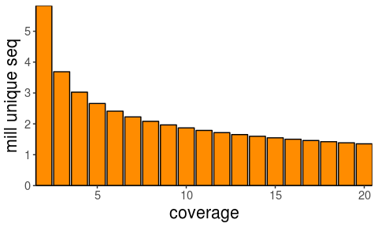

```r
uniqseq_loci <- read.csv("data/REF/uniqseq.data", sep="", header = FALSE,
                         col.names = c("COVERAGE", "N_READS")) %>%
  mutate(MILL_READS = N_READS/1000000)

ggplot(uniqseq_loci, aes(x = COVERAGE, y = MILL_READS)) +
  geom_bar(stat="identity", color = "black", fill = "darkorange") +
  scale_x_continuous(expand=c(0,0)) +
  scale_y_continuous(expand=c(0,0)) +
  labs(x = "coverage", y = "mill unique seq") +
  theme_standard
```

## Distribution of between individuals unique reads

In addition, dDocent creates the file `uniqseq.peri.data` which contains the number of unique sequences that occur in more than X individuals. By choosing a cut-off value the user determines in how many individuals a unique sequence must occur in order for it to be included in the reference. In initial value of approx. 10% of individuals is sufficient for intial reference construction.

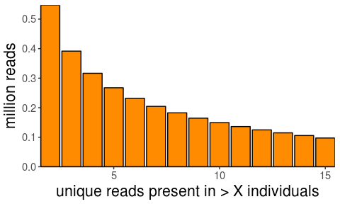

```r
uniqseq_ind <- read.csv("data/REF/uniqseq.peri.data", sep="", header = FALSE,
                        col.names = c("N_IND", "N_READS")) %>%
  mutate(MILL_READS = N_READS/1000000)

ggplot(uniqseq_ind, aes(x = N_IND, y = MILL_READS)) +
  geom_bar(stat="identity", color = "black", fill = "darkorange") +
  scale_x_continuous(expand=c(0,0)) +
  scale_y_continuous(expand=c(0,0)) +
  labs(x = "unique reads present in > X individuals",
       y = "million reads") +
  theme_standard
```

dDocent will generate a `fasta`-file containing all the loci included in the reference based on the chosen parameters. After initial reference construction, references for combinations of c, K1 and K2 should be generated and compared in terms of the number of loci and the quality of read mapping for individuals to be included in the data analysis.

# Optimize assembly parameters (c, K1 & K2)

## Choose c parameter

### Run `RefOpt`-Script

Before running dDocent ensure that `uniq.seq`-files (generated during intial dDocent run to create reference) are in same directory as reference optimizing script being executed from. Specificy `minK1`, `maxK1`, `minK2`, `maxK2`, `Assenmbly type` and `number of processors.

Output file `kopt.data` contains the number of reads in reference for each c, K1, K2 combination.

### Analyze `kopt`-output file

```r
# import output from RefOpt2.sh script
kopt <- read.table("data/REF/kopt.data", sep="", header = FALSE,
                   col.names = c("K1", "K2", "c", "N_CONTIGS"))
```

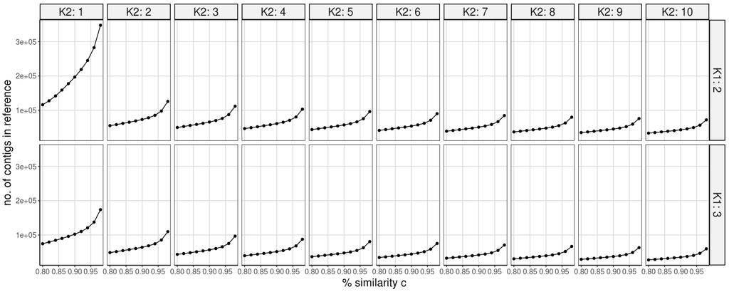

```r
# plot number of reads for each value of c for each K1 and K2 combination
ggplot(kopt, aes(x = c, y = N_CONTIGS)) +
  geom_point() +
  geom_line() +
  facet_grid(K1 ~ K2, labeller=label_both) +
  labs(x = "% similarity c", y = "no. of contigs in reference") +
  theme_facet
```

Compare the distribution of number of loci in each reference to the number of fragments expected per individual based on the cut-site frequencies and selected window (approx. 90,000).

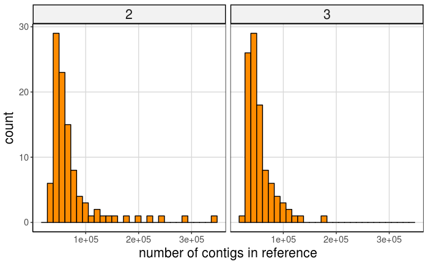

```r
# plot distribution
ggplot(kopt, aes(x = N_CONTIGS)) +
  geom_histogram(color = "black", fill = "darkorange") +
  facet_grid(~ K1) +
  labs(x = "number of contigs in reference") +
  theme_facet
```

For K2 = 2, reads must occur in at least ~10% of individuals used to create the reference to be included.

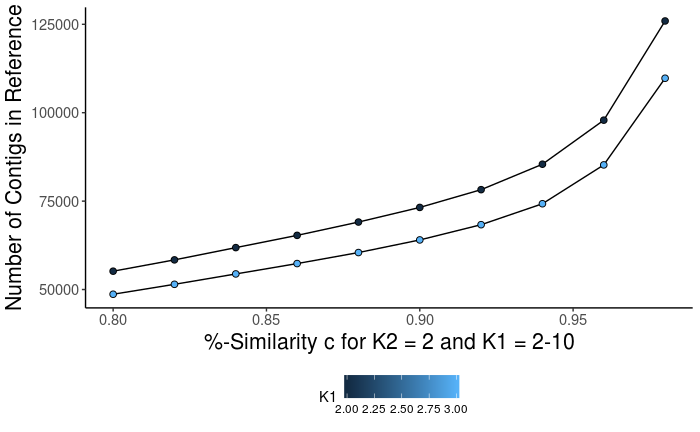

```r
# plot no. of reads vs. c for K2 = 2 K1 = 2-10
ggplot(kopt, aes(x = c, y = N_CONTIGS, fill = K1)) +
  geom_line(data = subset(kopt, K2 %in% 2), aes(group = K1), color = "black") +
  geom_point(data = subset(kopt, K2 %in% 2),
             shape = 21, size = 2, color = "black") +
  labs(x = "%-Similarity c for K2 = 2 and K1 = 2-10",
       y = "Number of Contigs in Reference") +
  theme_standard
```

The lower the cut-off values from K1 and K2, the more likely loci will be included that are due to individual variability and are not informative on a population level (which can unnecessarily increase computational time).

If the cut-off values are too high loci that are informative might be excluded, which could lead to ascertainment bias. The optimum values for K1 and K2 are best determined by analyzing the mapping statistics of individuals mapped to references created for a combination of K1 and K2 values after an optimum c-value has been determined. The user will be able to compare the number of reads mapped in general, the number of reads mapped in pairs, the number of unmapped reads and the distribution of coverage to determine the best combinations of K.

In general, for a value c < 0.88 - 0.9 the variance in the number of reads obtained is negligible, while there is an observable jump in the number of reads in the reference for values of c > 0.95. This is due to over-splitting of loci at higher values. The higher c the more similar stacks of reads have to be in order to be combined into one locus. It’s better to “undersplit” and then filter out loci later (e.g. as paralogs).

c-parameter chosen based on `kopt.data` results: **c = 0.8**

## Choose K1 and K2 cut-off values

### Assemble references for K1/K2 combinations

```r
K1 <- as.character(c(2:10))
K2 <- as.character(c(1:6))

path <- "/home/soleary/GAFFTOPS/BMA_POPGEN/data/REF/"
command <- "mkdir"

REF <- expand.grid(K1, K2) %>%
  mutate(temp = "REF",
         PATH = path,
         COMMAND = command) %>%
  select(COMMAND, PATH, temp, Var1, Var2) %>%
  unite(dir, 2:4, sep = "", remove = TRUE) %>%
  arrange(dir) %>%
  unite(PATH, 2:3, remove = TRUE)

write_delim(REF, "scr/mkdirREF.sh", col_names = FALSE)
```

Run bash script to write new directories:

```bash
chmod 755 scr/mkdirREF.sh
./scr/mkdirREF.sh
```

In each Reference directory create soft links to the demultiplexed (and quality trimmed) fastq files from the `REF_IND` directory, containing individuals to be used to create the reduced representation reference.

```r
miseq <- "/home/soleary/GAFFTOPS/BMA_POPGEN/data/REF/REF_IND/*.fq.gz"

command <- "ln -s"

SEQ <- REF %>%
  select(PATH) %>%
  mutate(COMMAND = command,
         SEQ = miseq) %>%
  select(COMMAND, SEQ, PATH)

write.table(SEQ, "scr/miseq_softlinks.sh",
            col.names = FALSE, quote = FALSE, row.names = FALSE)
```

Create softlinks in each folder:

```bash
chmod 755 scr/miseq_softlinks.sh
./scr/miseq_softlinks.sh
```

`dDocent` can be run using either a configuration files or interactively. The configuration file does not include options to input K1 and K2. Rather than do that manually, `dDocent` can be run in a shell script with all the inputs for the interactive use. Different versions of `dDocent` may have slightly different input needed so double check before creating shell scripts for reference construction.

```r
# parameters for shell script ----
# correct number of individuals
ind <- "yes"
# number of processors
processors <- "15"
# quality trim needed
trim <- "no"
# perform reference assembly
assembly <- "yes"
# read type (overlapping/miseq OL, paired end PE)
type <- "PE"
# used defined c-value
set_c <- "yes"
# set c-value
c <- "0.80"
# read mapping required
map <- "no"
# SNP calling required
snp <- "no"
# email address
email <- "shannon.j.oleary@gmail.com"
# K-values
K1 <- as.character(c(2:10))
K2 <- as.character(c(1:6))
# create dataframe with reference directory, K1 and K2 to loop over ----
# path to parent directory for references
path <- "/home/soleary/GAFFTOPS/BMA_POPGEN/data/REF/"
df <- expand.grid(K1, K2) %>%
  mutate(temp = "REF",
         PATH = path) %>%
  rename(K1 = Var1,
         K2 = Var2) %>%
  select(PATH, temp, K1, K2) %>%
  unite(dir, 2:3, sep = "", remove = FALSE) %>%
  select(- temp) %>%
  unite(dir, dir, K2, sep = "_", remove = FALSE) %>%
  unite(PATH, 1:2, sep = "") %>%
  rownames_to_column("REF_NUMBER") %>%
  mutate(REF_NUMBER = as.numeric(REF_NUMBER))
# write shell scripts in each directory ----
for(i in 1:nrow(df)){

  # select correct path and K1/K2 combination
  param <- df %>%
    filter(REF_NUMBER == i)

  # write shell script
  path <- glue(param$PATH, "/dDocent_refassembly.sh")

  con <- file(path, open = "wt")

  writeLines(glue("dDocent <<Over!
                  {ind}
                  {processors}
                  {trim}
                  {assembly}
                  {type}
                  {set_c}
                  {c}
                  {map}
                  {snp}
                  {email}
                  {param$K1}
                  {param$K2}
                  Over!"), con)

  close(con)

}
```

Within each `REF*`-directory, execute `dDocent` to initiate a run which will create a reference for the chosen c-value and K1/K2 data cut-offs.

```bash
# go to reference parent directory
cd /home/soleary/GAFFTOPS/BMA_POPGEN/data/REF/

# loop over all reference creation folders
for d in REF*_*

do

    ( cd "$d" && chmod 755 dDocent_refassembly.sh && ./dDocent_refassembly.sh)

done
```

Remove the softlinks to the MiSeq data used for mapping and other files generated during `dDocent`-run in each folder, so that only `reference.fasta` and associated files and stats files remain:

```r
# number of references generated
n <- 54

# create vector with n elements
files <- as.character(c(1:n))

# create dataframe with file names to be removed
files <- data.frame(files) %>%
  mutate(F1 = "*.fq.gz",
         F2 = "*.seqs",
         F3 = "*.fastq",
         F4 = "*.gz",
         F5 = "namelist",
         F6 = "uniqCperindv",
         F7 = "dDocent.runs",
         F8 = "xxx*",
         F9 = "fastp*",
         F10 = "total*",
         F11 = "uniq.full.*",
         F12 = "sort.*",
         F13 = "rainbow*",
         F14 = "overlap.*",
         F15 = "other*",
         F16 = "contig.*",
         F17 = "logfiles/") %>%
  select(-files)

# create combined dataframe of all ref directories and files to be removed
command <- "rm"

RM <- bind_cols(REF, files) %>%
  select(-COMMAND) %>%
  gather(key = temp, value = FILE, 2:18) %>%
  select(-temp) %>%
  unite(col = PATH, 1:2, sep = "/", remove = TRUE) %>%
  mutate(COMMAND = command) %>%
  select(COMMAND, PATH)

write.table(RM, "scr/remove-miseq.sh",
            col.names = FALSE, quote = FALSE, row.names = FALSE)
```

Remove unnecessary intermediate files

```bash
chmod 755 scr/remove-miseq.sh
./scr/remove-miseq.sh
```

### Map subset of individuals to assembled references

K1 and K2 are chosen based on mapping statistics of mapping HiSeq data to assembled references, i.e. HiSeq data needs to be demultiplexed and quality trimmed before it can be mapped. Create random set of high quality and low quality individuals from multiple locations to assess mapping quality.

```r
map_ind <- radtagslog %>%
  filter(!str_detect(SAMPLE, 'BLANK'),
         RETAINED > 500000) %>%
  group_by(LIBRARY) %>%
  sample_n(10, replace = FALSE) %>%
  ungroup()
```

Create folder for reference individuals.

```bash
mkdir /home/soleary/GAFFTOPS/BMA_POPGEN/data/REF/MAP_IND
```

Write bash script to copy `fastq` files of reference individuals from BMA1 into a single directory.

```r
path <- "/home/soleary/GAFFTOPS/BMA_POPGEN/data/REF/MAP_IND/"

seq_dir <- "/home/soleary/GAFFTOPS/BMA_POPGEN/data/SEQ/BMA-1/"

command <- "cp"

SEQ <- map_ind %>%
  filter(LIBRARY == "BMA1") %>%
  select(SAMPLE) %>%
  mutate(temp = ".*",
         dir = seq_dir) %>%
  unite(SEQ, dir, SAMPLE, temp, sep = "") %>%
  mutate(COMMAND = command,
         PATH = path) %>%
  select(COMMAND, SEQ, PATH)

write.table(SEQ, "scr/cp_mapind.sh",
            col.names = FALSE, quote = FALSE, row.names = FALSE)
```

Copy sequences of individuals to use for mapping in directory.

```bash
cd /home/soleary/GAFFTOPS/BMA_POPGEN

chmod 755 scr/cp_mapind.sh

./scr/cp_mapind.sh
```

Write bash script to copy `fastq` files of reference individuals from BMA2 into a single directory.

```r
path <- "/home/soleary/GAFFTOPS/BMA_POPGEN/data/REF/MAP_IND/"

seq_dir <- "/home/soleary/GAFFTOPS/BMA_POPGEN/data/SEQ/BMA-2/"

command <- "cp"

SEQ <- map_ind %>%
  filter(LIBRARY == "BMA2") %>%
  select(SAMPLE) %>%
  mutate(temp = ".*",
         dir = seq_dir) %>%
  unite(SEQ, dir, SAMPLE, temp, sep = "") %>%
  mutate(COMMAND = command,
         PATH = path) %>%
  select(COMMAND, SEQ, PATH)

write.table(SEQ, "scr/cp_mapind.sh",
            col.names = FALSE, quote = FALSE, row.names = FALSE)
```

Create softlinks of individuals to use for mapping in directory.

```bash
cd /home/soleary/GAFFTOPS/BMA_POPGEN

chmod 755 scr/cp_mapind.sh

./scr/cp_mapind.sh
```

Write bash script to copy `fastq` files of reference individuals from library 3 into a single directory.

```r
path <- "/home/soleary/GAFFTOPS/BMA_POPGEN/data/REF/MAP_IND/"

seq_dir <- "/home/soleary/GAFFTOPS/BMA_POPGEN/data/SEQ/BMA-3/"

command <- "cp"

SEQ <- map_ind %>%
  filter(LIBRARY == "BMA3") %>%
  select(SAMPLE) %>%
  mutate(temp = ".*",
         dir = seq_dir) %>%
  unite(SEQ, dir, SAMPLE, temp, sep = "") %>%
  mutate(COMMAND = command,
         PATH = path) %>%
  select(COMMAND, SEQ, PATH)

write.table(SEQ, "scr/cp_mapind.sh",
            col.names = FALSE, quote = FALSE, row.names = FALSE)
```

Create softlinks of individuals to use for mapping in directory.

```bash
cd /home/soleary/GAFFTOPS/BMA_POPGEN

chmod 755 scr/cp_mapind.sh

./scr/cp_mapind.sh
```

In each Reference directory create links to the demultiplexed and trimmed fastq files to use for mapping.

```r
# path to directory with untrimmed fastq files for 20 individuals
hiseq <- "/home/soleary/GAFFTOPS/BMA_POPGEN/data/REF/MAP_IND/*.fq.gz"

command <- "ln -s"

# create dataframe to create softlinks in each reference directory
SEQ <- REF %>%
  select(PATH) %>%
  mutate(COMMAND = command,
         SEQ = hiseq) %>%
  select(COMMAND, SEQ, PATH)

# write script to file
write.table(SEQ, "scr/hiseq_softlinks.sh",
            col.names = FALSE, quote = FALSE, row.names = FALSE)
```

```bash
chmod 755 scr/hiseq_softlinks.sh
./scr/hiseq_softlinks.sh
```

Write configuration file to run dDocent in each reference directory.

```r
# parameters for shell script ----

# correct number of individuals
ind <- "yes"

# number of processors
processors <- "25"

# quality trim needed
trim <- "no"

# perform reference assembly
assembly <- "no"

# read mapping required
map <- "yes"

# custom values for mapping
map_param <- "yes"

# match score
A <- "1"

# mismatch score
B <- "3"

# gap penalty
O <- "5"

# SNP calling required
snp <- "yes"

# email address
email <- "shannon.j.oleary@gmail.com"

# create dataframe with reference directory, K1 and K2 to loop over ----

# path to parent directory for references
path <- "/home/soleary/GAFFTOPS/BMA_POPGEN/data/REF/"


df <- expand.grid(K1, K2) %>%
  mutate(temp = "REF",
         PATH = path) %>%
  rename(K1 = Var1,
         K2 = Var2) %>%
  select(PATH, temp, K1, K2) %>%
  unite(dir, 2:3, sep = "", remove = FALSE) %>%
  select(- temp) %>%
  unite(dir, dir, K2, sep = "_", remove = FALSE) %>%
  unite(PATH, 1:2, sep = "") %>%
  rownames_to_column("REF_NUMBER") %>%
  mutate(REF_NUMBER = as.numeric(REF_NUMBER))

# write shell scripts in each directory ----

for(i in 1:nrow(df)){

  # select correct path and K1/K2 combination
  param <- df %>%
    filter(REF_NUMBER == i)

  # write shell script
  path <- glue(param$PATH, "/dDocent_map.sh")

  con <- file(path, open = "wt")

  writeLines(glue("dDocent <<Over!
                  {ind}
                  {processors}
                  {trim}
                  {assembly}
                  {map}
                  {map_param}
                  {A}
                  {B}
                  {O}
                  {snp}
                  {email}
                  Over!"), con)

  close(con)

}
```

Execute `dDocent` from within each reference folder to initiate a run to map those individuals to the generated references and call SNPs.

```bash
# go to reference parent directory
cd /home/soleary/GAFFTOPS/BMA_POPGEN/data/REF/

# loop over all reference creation folders
for d in REF*_*

do

    ( cd "$d" && chmod 755 dDocent_map.sh && ./dDocent_map.sh)

done
```

Write file to remove softlinks to hiseq sequence files.

```r
command <- "rm"

RM <- REF %>%
  mutate(COMMAND = command,
         FASTQ = "*.fq.gz") %>%
  unite(FILE, PATH, FASTQ, sep = "/", remove = TRUE)

# write script to file
write.table(RM, "scr/rm-hiseq.sh",
            col.names = FALSE, quote = FALSE, row.names = FALSE)
```

Remove fastq files.

```bash
chmod 755 scr/rm-hiseq.sh
./scr/rm-hiseq.sh
```

Write file to remove `covstats` files.

```r
command <- "rm"

RM <- REF %>%
  mutate(COMMAND = command,
         FASTQ = "*.cov.stats") %>%
  unite(FILE, PATH, FASTQ, sep = "/", remove = TRUE)

# write script to file
write.table(RM, "scr/rm-covstats.sh",
            col.names = FALSE, quote = FALSE, row.names = FALSE)
```

Remove fastq files.

```bash
chmod 755 scr/rm-covstats.sh
./scr/rm-covstats.sh
```

### Query mapping statistics

During the mapping stage, `dDocent` calls `BWA` to map reads from the individuals in the folder to the generated MiSeqReference and create a `-RG.bam`-file for each individual. The second column of a BAM (or SAM) file contains FLAGs with binary encoded information on mapping, pairedness etc. that can be used to compare the mapping efficiency of the generated MiSeq references.

Count number of reads and mapped reads using `samtools idxstats <aln-RG.bam>` which will retrieve and print stats in the bam-file. The output is TAB-delimited with each line consisting of reference sequence name, sequence length, # mapped reads and # unmapped (empty) reads. `samtools` can also be be used to query `samtools flagstat file.bam` which returns an output containing the number of reads for which each flag is true.

#### Run Flagstats

```bash
cd /home/soleary/GAFFTOPS/BMA_POPGEN/data/REF/MAP_IND

ls -lh >> test.ind
```

Write script to gather flagstats from all `bam`-files.

```r
bam <- read.table("data/REF/MAP_IND/test.ind",
                  header = FALSE, skip = 1, stringsAsFactors = FALSE) %>%
  filter(!V9 == "test.ind") %>%
  separate(V9, into = c("IND", "temp"), -9) %>%
  filter(temp %in% c(".R1.fq.gz", ".R2.fq.gz")) %>%
  mutate(FILE = "-RG.bam") %>%
  unite(BAM, IND, FILE, sep = "") %>%
  select(BAM) %>%
  distinct()

bam <- as.data.frame(t(bam)) %>%
  mutate(COMMAND = "samtools flagstat",
         OUT = ">> REF.flagstats") %>%
  gather(key = IND, value = FILE, 1:30) %>%
  select(COMMAND, FILE, OUT)

write.table(bam, "scr/flagstats.sh",
            col.names = FALSE, quote = FALSE, row.names = FALSE)

# write script to place copy of configuration file in each reference directory
scr <- "/home/soleary/GAFFTOPS/BMA_POPGEN/scr/flagstats.sh"

command <- "cp"

# create dataframe to create softlinks in each reference directory
CP <- REF %>%
  mutate(COMMAND = command,
         FILE = scr) %>%
  select(COMMAND, FILE, PATH)

# write script to file
write.table(CP, "scr/copy_flagstats.sh",
            col.names = FALSE, quote = FALSE, row.names = FALSE)
```

Copy flagstats.

```bash
chmod 755 scr/copy_flagstats.sh
./scr/copy_flagstats.sh
```

Create script to run flagstats for all references.

```r
command <- "cd"

df <- REF %>%
  mutate(COMMAND = command,
         temp = c(1:nrow(REF)),
         CHMOD = "chmod 755 flagstats.sh",
         EXECUTE = "./flagstats.sh")

df1 <- df %>%
  select(temp, CHMOD) %>%
  rename(col1 = CHMOD)

df2 <- df %>%
  select(temp, EXECUTE) %>%
  rename(col1 = EXECUTE)

df3 <- df %>%
  select(temp, COMMAND, PATH) %>%
  unite(col1, COMMAND, PATH, sep = " ", remove = TRUE)

FLAG <- bind_rows(df3, df1)

FLAG <- bind_rows(FLAG, df2) %>%
           arrange(temp) %>%
  select(-temp)

# write script to file
write.table(FLAG, "scr/run_flagstats.sh",
            col.names = FALSE, quote = FALSE, row.names = FALSE)
```

Run flagstats.

```bash
chmod 755 scr/run_flagstats.sh
./scr/run_flagstats.sh
```

Need to rename and copy into results folder.

```r
K1 <- as.character(c(2:10))
K2 <- as.character(c(1:6))

rename <- expand.grid(K1, K2) %>%
  mutate(temp = "REF",
         ending = ".flagstats") %>%
  select(temp, Var1, Var2, ending) %>%
  unite(REF, 1:4, sep = "") %>%
  arrange(REF) %>%
  mutate(mv = "mv REF.flagstats",
         temp = c(1:54)) %>%
  select(temp, mv, REF) %>%
  unite(col1, mv, REF, sep = " ")

# View(rename)

command <- "cd"

df <- REF %>%
  mutate(COMMAND = command,
         temp = c(1:nrow(REF)),
         MV = "mv *.flagstats /home/soleary/GAFFTOPS/BMA_POPGEN/results/")

df1 <- df %>%
  select(temp, COMMAND, PATH) %>%
  unite(col1, COMMAND, PATH, sep = " ", remove = TRUE)

df2 <- df %>%
  select(temp, MV) %>%
  rename(col1 = MV)

MV <- bind_rows(df1, rename)

MV <- bind_rows(MV, df2) %>%
           arrange(temp) %>%
  select(-temp)

# View(MV)

# write script to file
write.table(MV, "scr/move_flagstats.sh",
            col.names = FALSE, quote = FALSE, row.names = FALSE)
```

Execute:

```bash
chmod 755 scr/move_flagstats.sh
./scr/move_flagstats.sh
```

#### Run idxstats

Write script to gather idxstats from all `bam`-files.

```r
bam <- read.table("data/REF/MAP_IND/test.ind",
                  header = FALSE, skip = 1, stringsAsFactors = FALSE) %>%
  filter(!V9 == "test.ind") %>%
  separate(V9, into = c("IND", "temp"), -9) %>%
  filter(temp %in% c(".R1.fq.gz", ".R2.fq.gz")) %>%
  mutate(FILE = "-RG.bam") %>%
  unite(BAM, IND, FILE, sep = "") %>%
  select(BAM) %>%
  distinct()

bam <- as.data.frame(t(bam)) %>%
  mutate(COMMAND = "samtools idxstats",
         OUT = ">> REF.idxstats") %>%
  gather(key = IND, value = FILE, 1:30) %>%
  select(COMMAND, FILE, OUT)

write.table(bam, "scr/idxstats.sh",
            col.names = FALSE, quote = FALSE, row.names = FALSE)

# write script to place copy of configuration file in each reference directory
scr <- "/home/soleary/GAFFTOPS/BMA_POPGEN/scr/idxstats.sh"

command <- "cp"

# create dataframe to create softlinks in each reference directory
CP <- REF %>%
  mutate(COMMAND = command,
         FILE = scr) %>%
  select(COMMAND, FILE, PATH)

# write script to file
write.table(CP, "scr/copy_idxstats.sh",
            col.names = FALSE, quote = FALSE, row.names = FALSE)
```

Copy idxstats.

```bash
chmod 755 scr/copy_idxstats.sh
./scr/copy_idxstats.sh
```

Create script to run idxstats for all references.

```r
command <- "cd"

df <- REF %>%
  mutate(COMMAND = command,
         temp = c(1:nrow(REF)),
         CHMOD = "chmod 755 idxstats.sh",
         EXECUTE = "./idxstats.sh")

df1 <- df %>%
  select(temp, CHMOD) %>%
  rename(col1 = CHMOD)

df2 <- df %>%
  select(temp, EXECUTE) %>%
  rename(col1 = EXECUTE)

df3 <- df %>%
  select(temp, COMMAND, PATH) %>%
  unite(col1, COMMAND, PATH, sep = " ", remove = TRUE)

FLAG <- bind_rows(df3, df1)

FLAG <- bind_rows(FLAG, df2) %>%
           arrange(temp) %>%
  select(-temp)

# write script to file
write.table(FLAG, "scr/run_idxstats.sh",
            col.names = FALSE, quote = FALSE, row.names = FALSE)
```

Run idxstats.

```bash
chmod 755 scr/run_idxstats.sh
./scr/run_idxstats.sh
```

Need to rename and copy into results folder.

```r
K1 <- as.character(c(2:10))
K2 <- as.character(c(1:6))

rename <- expand.grid(K1, K2) %>%
  mutate(temp = "REF",
         ending = ".idxstats") %>%
  select(temp, Var1, Var2, ending) %>%
  unite(REF, 1:4, sep = "") %>%
  arrange(REF) %>%
  mutate(mv = "mv REF.idxstats",
         temp = c(1:54)) %>%
  select(temp, mv, REF) %>%
  unite(col1, mv, REF, sep = " ")

View(rename)

command <- "cd"

df <- REF %>%
  mutate(COMMAND = command,
         temp = c(1:nrow(REF)),
         MV = "mv *.idxstats /home/soleary/GAFFTOPS/BMA_POPGEN/results/")

df1 <- df %>%
  select(temp, COMMAND, PATH) %>%
  unite(col1, COMMAND, PATH, sep = " ", remove = TRUE)

df2 <- df %>%
  select(temp, MV) %>%
  rename(col1 = MV)

MV <- bind_rows(df1, rename)

MV <- bind_rows(MV, df2) %>%
           arrange(temp) %>%
  select(-temp)

View(MV)

# write script to file
write.table(MV, "scr/move_idxstats.sh",
            col.names = FALSE, quote = FALSE, row.names = FALSE)
```

Execute:

```bash
chmod 755 scr/move_idxstats.sh
./scr/move_idxstats.sh
```

#### Format stats files into tidy data sets

Appending the file results in the information per individual being printed in a new set of row being appended to the file, i.e. there will be as many rows for a given locus as individuals were mapped. The file can be re-formatted and summary statistics calculated using dplyr and tidyr.

Format idxstats

```r
# having max value for K2 = 10 causing problems (2 digits); need to manually edit

# create vectors of files to be imported, reference codes, K1 and K2, dataframe names
filenames <- list.files(path = "results", pattern = "*.idxstats")

ref_code <- str_sub(filenames, 4, -10)

k1_list <- str_sub(ref_code, 1, -2)

k2_list <- str_sub(ref_code, start = -1)

names <- str_sub(filenames, 1, -6)

# import data
for (i in names){
  filepath <- file.path("results", paste(i, 'stats', sep =""))
  assign(i, read.table(filepath, sep = "", header = FALSE,
                     col.names = c("Locus", "Length", "Reads_Mapped", 'blank')) %>%
           select(1:3))
  }

# Create list of one dataframe per idxstats file and group by locus
# make sure to delete old list if rerunning the code
rm(dflist_idx)

dflist_idx <- lapply(ls(pattern = "*.idx"), get)

for (df in 1:length(dflist_idx)){
  x <- dflist_idx[[df]]
  x[['Locus']] <- as.character(x[['Locus']])
  x = x %>% group_by(Locus)
  dflist_idx[[df]] <- x
}

# Create new dataframes with summary stats per REF bind into final output/dataframe
RefMapStats.idx <- data.frame()

for (df in 1:length(dflist_idx)){
  x = summarize(dflist_idx[[df]],
                Length = mean(Length),
                Mean_Mapped = mean(Reads_Mapped),
                Sum_Mapped = sum(Reads_Mapped),
                Min_Mapped = min(Reads_Mapped),
                Max_Mapped = max(Reads_Mapped),
                SD_Mapped = sd(Reads_Mapped))
  x[x == 0] <- NA

  temp <- summarize(x, Mean_Mapped_Non0 = mean(Mean_Mapped, na.rm = TRUE)) %>%
    mutate(K1 = k1_list[df],
           K2 = k2_list[df],
           REF = ref_code[df],
           Not_Mapped = nrow(filter(x, is.na(Sum_Mapped))),
           N_Loci_Ref = nrow(x)) %>%
    select(K1, K2, REF, N_Loci_Ref, Not_Mapped, Mean_Mapped_Non0)

  RefMapStats.idx <- bind_rows(RefMapStats.idx, temp)
}

write_delim(RefMapStats.idx, "results/RefMapStats.idx", delim = "\t")
```

Format flagstats

```r
# Files to be imported
filenames <- list.files(path='results', pattern = '*.flagstats')

# create vectors of files to be imported
names <- str_sub(filenames, 1, -6)

# import data
for (i in names){
  filepath <- file.path('results', paste(i, 'stats', sep =""))
  assign(i, read.csv(filepath, sep = "+", header = FALSE,
                     col.names = c("N_Reads", "CAT"),
                     stringsAsFactors = FALSE) %>%
           select(1:2))
}

rm(dflist_flag)

# Create list of one dataframe per flagstats file and create tidy data set
# should be 60 - 1 elements/references
dflist_flag <- lapply(ls(pattern = "*flag"), get)
# dflist_flag <- dflist_flag[-1]
# dflist_flag <- dflist_flag[-61]


# Change N_Reads to numeric
for (df in 1:length(dflist_flag)){
  x <- dflist_flag[[df]]
  x[['N_Reads']] <- as.numeric(x[['N_Reads']])
  dflist_flag[[df]] <- x
}

# number of individuals mapped
n <- 30

for (df in 1:length(dflist_flag)){
  x <- dflist_flag[[df]]

  x <- x %>%
    filter(grepl("0 mapped|properly paired|mapQ>=5", CAT)) %>%
    mutate(MAPSTAT = ifelse(grepl("mapQ>=5", CAT), "Mismatch",
                   ifelse(grepl("properly", CAT), "Prop_Paired", "Mapped"))) %>%
    mutate(Ind = c(rep(1:n, each = 3))) %>%
    # not sure if extra individual in there somehow
    select(4, 3, 1) %>%
    spread(MAPSTAT, N_Reads)

  dflist_flag[[df]] <- x
}

temp <- dflist_flag[[df]]

# Create new dataframes with summary stats and add to main final data frame
RefMapStats.flag <- data.frame()
for (df in 1:length(dflist_flag)){
  x = summarize(dflist_flag[[df]], Sum_Mapped = sum(Mapped),
                             Reads_Mapped = mean(Mapped),
                             Sum_Paired = sum(Prop_Paired),
                             Mean_Paired = mean(Prop_Paired),
                             Sum_Mismatch = sum(Mismatch),
                             Mean_Mismatch = mean(Mismatch)) %>%
  mutate(K1 = k1_list[df], K2 = k2_list[df], REF = ref_code[df]) %>%
  select(7:9, 1:6)
  RefMapStats.flag <- bind_rows(RefMapStats.flag, x)
}

write_delim(RefMapStats.flag, "results/RefMapStats.flag", delim = "\t")

# create combined data set
RefMapStats <- left_join(RefMapStats.idx, RefMapStats.flag) # %>%

# write summary stats file
write_delim(RefMapStats, "results/RefMapStats.txt", delim = "\t")
```

### Evaluate & compare mapping results

Compare number of loci in the reference with no reads mapped to.

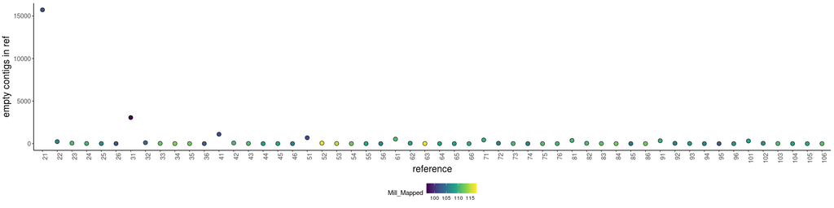

Choosing cut-off values for K1 and K2 are a trade-off between maximizing the number of reads in the reference and the number of reads mapped while minimizing the number of reads that are not mapped as a pair.

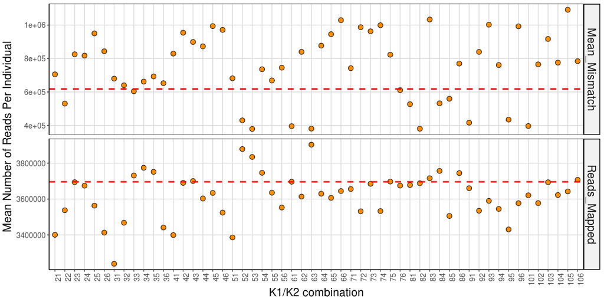

```r
# create tidy data set for plotting
RefMapStats_tidy <- RefMapStats %>%
  select(K1, K2, REF, N_Loci_Ref, Mean_Mismatch, Reads_Mapped) %>%
  gather("MAP_STAT", "READS", Mean_Mismatch:Reads_Mapped)

# calculate 25% and 75% percentile for mismatched and total mapped reads
MEAN_MISMATCH25 <- unname(quantile(RefMapStats$Mean_Mismatch, 0.25))
READSMAPPED75 <- unname(quantile(RefMapStats$Reads_Mapped, 0.75))
LOCI50 <- unname(quantile(RefMapStats$N_Loci_Ref, c(0.5, .75)))

Percentile <- data.frame(MAP_STAT = c('Mean_Mismatch','Reads_Mapped'),
                      yint = with(RefMapStats_tidy,
                                  c(MEAN_MISMATCH25, READSMAPPED75)))

# plot indicating lowest & highest 25%
ggplot(RefMapStats_tidy, aes(x = REF, y = READS)) +
  geom_point(shape = 21, size = 3, color = "black", fill = "darkorange") +
  geom_hline(data = Percentile, aes(yintercept = yint),
             color = "red", linetype = "dashed", size = 1) +
  facet_grid(MAP_STAT ~ ., scales = "free") +
  labs(x = "K1/K2 combination",
       y = "Mean Number of Reads Per Individual") +
  theme_facet +
  theme(axis.text.x = element_text(angle = 90, hjust = 1))
```

Reference below the dashed line (25th percentile) for mean number of mismatched paired reads and above the red dashed line (75th percentile) of mean number of reads mapped.

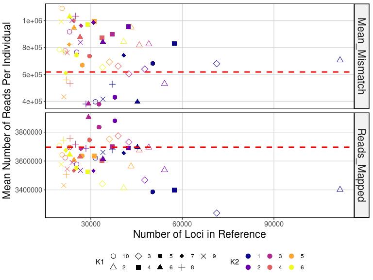

```r
# plot indicating 50 and 75% for number of loci in reference
RefMapStats_tidy$K1 <- as.character(RefMapStats_tidy$K1)
RefMapStats_tidy$K2 <- as.character(RefMapStats_tidy$K2)

ggplot(RefMapStats_tidy, aes(x = N_Loci_Ref, y = READS, color = K2, shape = K1)) +
  geom_point(size = 3) +
  geom_hline(data = Percentile, aes(yintercept = yint),
             color = "red", linetype = "dashed", size = 1) +
  scale_shape_manual(values = c(1, 2, 5, 15, 16, 17, 18, 3, 4)) +
  scale_color_viridis(discrete = TRUE, option = "C") +
  facet_grid(MAP_STAT ~ ., scales = "free") +
  labs(x = "Number of Loci in Reference",
       y = "Mean Number of Reads Per Individual") +
  theme_facet
```

### Query SNP calling stats

Query stats

```bash
# REF33
vcftools --vcf data/REF/REF3_3/TotalRawSNPs.vcf --out data/REF/REF3_3/raw --depth
vcftools --vcf data/REF/REF3_3/TotalRawSNPs.vcf --out data/REF/REF3_3/raw --site-mean-depth
vcftools --vcf data/REF/REF3_3/TotalRawSNPs.vcf --out data/REF/REF3_3/raw --missing-indv
vcftools --vcf data/REF/REF3_3/TotalRawSNPs.vcf --out data/REF/REF3_3/raw --missing-site
vcftools --vcf data/REF/REF3_3/TotalRawSNPs.vcf --out data/REF/REF3_3/raw --site-quality

vcftools --vcf data/REF/REF3_3/TotalRawSNPs.vcf --out data/REF/REF3_3/fil --minQ 20 --mac 3 --minDP 3 --min-meanDP 15 --recode --recode-INFO-all

vcftools --vcf data/REF/REF3_3/fil.recode.vcf --out data/REF/REF3_3/fil --missing-indv
vcftools --vcf data/REF/REF3_3/fil.recode.vcf --out data/REF/REF3_3/fil --missing-site

# REF52
vcftools --vcf data/REF/REF5_2/TotalRawSNPs.vcf --out data/REF/REF5_2/raw --depth
vcftools --vcf data/REF/REF5_2/TotalRawSNPs.vcf --out data/REF/REF5_2/raw --site-mean-depth
vcftools --vcf data/REF/REF5_2/TotalRawSNPs.vcf --out data/REF/REF5_2/raw --missing-indv
vcftools --vcf data/REF/REF5_2/TotalRawSNPs.vcf --out data/REF/REF5_2/raw --missing-site
vcftools --vcf data/REF/REF5_2/TotalRawSNPs.vcf --out data/REF/REF5_2/raw --site-quality

vcftools --vcf data/REF/REF5_2/TotalRawSNPs.vcf --out data/REF/REF5_2/fil --minQ 20 --mac 3 --minDP 3 --min-meanDP 15 --recode --recode-INFO-all

vcftools --vcf data/REF/REF5_2/fil.recode.vcf --out data/REF/REF5_2/fil --missing-indv
vcftools --vcf data/REF/REF5_2/fil.recode.vcf --out data/REF/REF5_2/fil --missing-site

# REF53
vcftools --vcf data/REF/REF5_3/TotalRawSNPs.vcf --out data/REF/REF5_3/raw --depth
vcftools --vcf data/REF/REF5_3/TotalRawSNPs.vcf --out data/REF/REF5_3/raw --site-mean-depth
vcftools --vcf data/REF/REF5_3/TotalRawSNPs.vcf --out data/REF/REF5_3/raw --missing-indv
vcftools --vcf data/REF/REF5_3/TotalRawSNPs.vcf --out data/REF/REF5_3/raw --missing-site
vcftools --vcf data/REF/REF5_3/TotalRawSNPs.vcf --out data/REF/REF5_3/raw --site-quality

vcftools --vcf data/REF/REF5_3/TotalRawSNPs.vcf --out data/REF/REF5_3/fil --minQ 20 --mac 3 --minDP 3 --min-meanDP 15 --recode --recode-INFO-all

vcftools --vcf data/REF/REF5_3/fil.recode.vcf --out data/REF/REF5_3/fil --missing-indv
vcftools --vcf data/REF/REF5_3/fil.recode.vcf --out data/REF/REF5_3/fil --missing-site

# REF61
vcftools --vcf data/REF/REF6_1/TotalRawSNPs.vcf --out data/REF/REF6_1/raw --depth
vcftools --vcf data/REF/REF6_1/TotalRawSNPs.vcf --out data/REF/REF6_1/raw --site-mean-depth
vcftools --vcf data/REF/REF6_1/TotalRawSNPs.vcf --out data/REF/REF6_1/raw --missing-indv
vcftools --vcf data/REF/REF6_1/TotalRawSNPs.vcf --out data/REF/REF6_1/raw --missing-site
vcftools --vcf data/REF/REF6_1/TotalRawSNPs.vcf --out data/REF/REF6_1/raw --site-quality

vcftools --vcf data/REF/REF6_1/TotalRawSNPs.vcf --out data/REF/REF6_1/fil --minQ 20 --mac 3 --minDP 3 --min-meanDP 15 --recode --recode-INFO-all

vcftools --vcf data/REF/REF6_1/fil.recode.vcf --out data/REF/REF6_1/fil --missing-indv
vcftools --vcf data/REF/REF6_1/fil.recode.vcf --out data/REF/REF6_1/fil --missing-site

# REF63
vcftools --vcf data/REF/REF6_3/TotalRawSNPs.vcf --out data/REF/REF6_3/raw --depth
vcftools --vcf data/REF/REF6_3/TotalRawSNPs.vcf --out data/REF/REF6_3/raw --site-mean-depth
vcftools --vcf data/REF/REF6_3/TotalRawSNPs.vcf --out data/REF/REF6_3/raw --missing-indv
vcftools --vcf data/REF/REF6_3/TotalRawSNPs.vcf --out data/REF/REF6_3/raw --missing-site
vcftools --vcf data/REF/REF6_3/TotalRawSNPs.vcf --out data/REF/REF6_3/raw --site-quality

vcftools --vcf data/REF/REF6_3/TotalRawSNPs.vcf --out data/REF/REF6_3/fil --minQ 20 --mac 3 --minDP 3 --min-meanDP 15 --recode --recode-INFO-all

vcftools --vcf data/REF/REF6_3/fil.recode.vcf --out data/REF/REF6_3/fil --missing-indv
vcftools --vcf data/REF/REF6_3/fil.recode.vcf --out data/REF/REF6_3/fil --missing-site
```

### Evaluate SNP data sets

Missing data

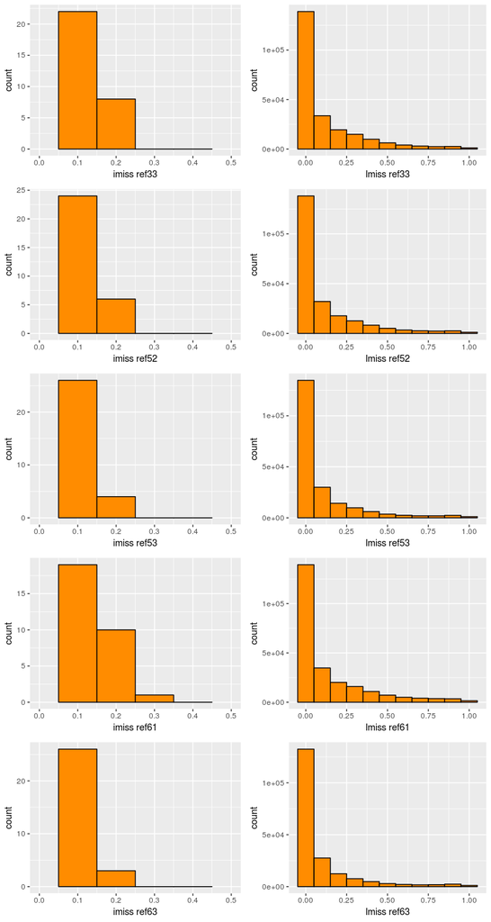

```r
p1 <- read.table("data/REF/REF3_3/raw.imiss",
           header = TRUE, stringsAsFactors = FALSE) %>%
  ggplot() +
  geom_histogram(aes(x = F_MISS),
                 binwidth = 0.1, fill = "darkorange", color = "black") +
  labs(x = "imiss ref33") +
  scale_x_continuous(limits = c(0, 0.5))

p10 <- read.table("data/REF/REF3_3/raw.lmiss",
           header = TRUE, stringsAsFactors = FALSE) %>%
  ggplot() +
  geom_histogram(aes(x = F_MISS),
                 binwidth = 0.1, fill = "darkorange", color = "black") +
  labs(x = "lmiss ref33")

p2 <- read.table("data/REF/REF5_2/raw.imiss",
           header = TRUE, stringsAsFactors = FALSE) %>%
  ggplot() +
  geom_histogram(aes(x = F_MISS),
                 binwidth = 0.1, fill = "darkorange", color = "black") +
  labs(x = "imiss ref52") +
  scale_x_continuous(limits = c(0, 0.5))

p11 <- read.table("data/REF/REF5_2/raw.lmiss",
           header = TRUE, stringsAsFactors = FALSE) %>%
  ggplot() +
  geom_histogram(aes(x = F_MISS),
                 binwidth = 0.1, fill = "darkorange", color = "black") +
  labs(x = "lmiss ref52")

p3 <- read.table("data/REF/REF5_3/raw.imiss",
           header = TRUE, stringsAsFactors = FALSE) %>%
  ggplot() +
  geom_histogram(aes(x = F_MISS),
                 binwidth = 0.1, fill = "darkorange", color = "black") +
  labs(x = "imiss ref53") +
  scale_x_continuous(limits = c(0, 0.5))

p12 <- read.table("data/REF/REF5_3/raw.lmiss",
           header = TRUE, stringsAsFactors = FALSE) %>%
  ggplot() +
  geom_histogram(aes(x = F_MISS),
                 binwidth = 0.1, fill = "darkorange", color = "black") +
  labs(x = "lmiss ref53")

p4 <- read.table("data/REF/REF6_1/raw.imiss",
           header = TRUE, stringsAsFactors = FALSE) %>%
  ggplot() +
  geom_histogram(aes(x = F_MISS),
                 binwidth = 0.1, fill = "darkorange", color = "black") +
  labs(x = "imiss ref61") +
  scale_x_continuous(limits = c(0, 0.5))

p13 <- read.table("data/REF/REF6_1/raw.lmiss",
           header = TRUE, stringsAsFactors = FALSE) %>%
  ggplot() +
  geom_histogram(aes(x = F_MISS),
                 binwidth = 0.1, fill = "darkorange", color = "black") +
  labs(x = "lmiss ref61")

p5 <- read.table("data/REF/REF6_3/raw.imiss",
           header = TRUE, stringsAsFactors = FALSE) %>%
  ggplot() +
  geom_histogram(aes(x = F_MISS),
                 binwidth = 0.1, fill = "darkorange", color = "black") +
  labs(x = "imiss ref63") +
  scale_x_continuous(limits = c(0, 0.5))

p14 <- read.table("data/REF/REF6_3/raw.lmiss",
           header = TRUE, stringsAsFactors = FALSE) %>%
  ggplot() +
  geom_histogram(aes(x = F_MISS),
                 binwidth = 0.1, fill = "darkorange", color = "black") +
  labs(x = "lmiss ref63")

multiplot(p1, p2, p3, p4, p5, p10, p11, p12, p13, p14, cols = 2)
```

Missing data after filtering

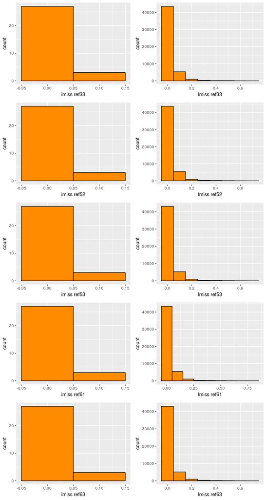

```r
p1 <- read.table("data/REF/REF3_3/fil.imiss",
           header = TRUE, stringsAsFactors = FALSE) %>%
  ggplot() +
  geom_histogram(aes(x = F_MISS),
                 binwidth = 0.1, fill = "darkorange", color = "black") +
  labs(x = "imiss ref33")

p10 <- read.table("data/REF/REF3_3/fil.lmiss",
           header = TRUE, stringsAsFactors = FALSE) %>%
  ggplot() +
  geom_histogram(aes(x = F_MISS),
                 binwidth = 0.1, fill = "darkorange", color = "black") +
  labs(x = "lmiss ref33")

p2 <- read.table("data/REF/REF5_2/fil.imiss",
           header = TRUE, stringsAsFactors = FALSE) %>%
  ggplot() +
  geom_histogram(aes(x = F_MISS),
                 binwidth = 0.1, fill = "darkorange", color = "black") +
  labs(x = "imiss ref52")

p11 <- read.table("data/REF/REF5_2/fil.lmiss",
           header = TRUE, stringsAsFactors = FALSE) %>%
  ggplot() +
  geom_histogram(aes(x = F_MISS),
                 binwidth = 0.1, fill = "darkorange", color = "black") +
  labs(x = "lmiss ref52")

p3 <- read.table("data/REF/REF5_3/fil.imiss",
           header = TRUE, stringsAsFactors = FALSE) %>%
  ggplot() +
  geom_histogram(aes(x = F_MISS),
                 binwidth = 0.1, fill = "darkorange", color = "black") +
  labs(x = "imiss ref53")

p12 <- read.table("data/REF/REF5_3/fil.lmiss",
           header = TRUE, stringsAsFactors = FALSE) %>%
  ggplot() +
  geom_histogram(aes(x = F_MISS),
                 binwidth = 0.1, fill = "darkorange", color = "black") +
  labs(x = "lmiss ref53")

p4 <- read.table("data/REF/REF6_1/fil.imiss",
           header = TRUE, stringsAsFactors = FALSE) %>%
  ggplot() +
  geom_histogram(aes(x = F_MISS),
                 binwidth = 0.1, fill = "darkorange", color = "black") +
  labs(x = "imiss ref61")

p13 <- read.table("data/REF/REF6_1/fil.lmiss",
           header = TRUE, stringsAsFactors = FALSE) %>%
  ggplot() +
  geom_histogram(aes(x = F_MISS),
                 binwidth = 0.1, fill = "darkorange", color = "black") +
  labs(x = "lmiss ref61")

p5 <- read.table("data/REF/REF6_3/fil.imiss",
           header = TRUE, stringsAsFactors = FALSE) %>%
  ggplot() +
  geom_histogram(aes(x = F_MISS),
                 binwidth = 0.1, fill = "darkorange", color = "black") +
  labs(x = "imiss ref63")

p14 <- read.table("data/REF/REF6_3/fil.lmiss",
           header = TRUE, stringsAsFactors = FALSE) %>%
  ggplot() +
  geom_histogram(aes(x = F_MISS),
                 binwidth = 0.1, fill = "darkorange", color = "black") +
  labs(x = "lmiss ref63")

multiplot(p1, p2, p3, p4, p5, p10, p11, p12, p13, p14, cols = 2)
```

Depth data (raw)

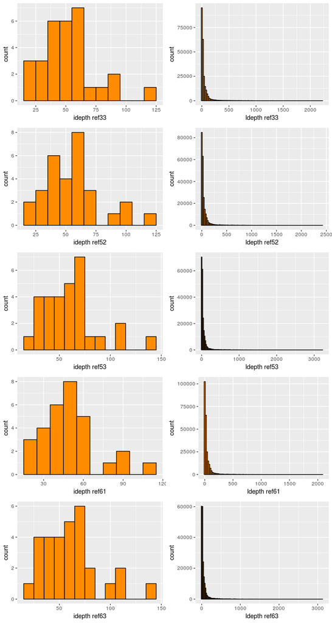

```r
p1 <- read.table("data/REF/REF3_3/raw.idepth",
           header = TRUE, stringsAsFactors = FALSE) %>%
  ggplot() +
  geom_histogram(aes(x = MEAN_DEPTH),
                 binwidth = 10, fill = "darkorange", color = "black") +
  labs(x = "idepth ref33")

p10 <- read.table("data/REF/REF3_3/raw.ldepth.mean",
           header = TRUE, stringsAsFactors = FALSE) %>%
  ggplot() +
  geom_histogram(aes(x = MEAN_DEPTH),
                 binwidth = 20, fill = "darkorange", color = "black") +
  labs(x = "ldepth ref33")

p2 <- read.table("data/REF/REF5_2/raw.idepth",
           header = TRUE, stringsAsFactors = FALSE) %>%
  ggplot() +
  geom_histogram(aes(x = MEAN_DEPTH),
                 binwidth = 10, fill = "darkorange", color = "black") +
  labs(x = "idepth ref52")

p11 <- read.table("data/REF/REF5_2/raw.ldepth.mean",
           header = TRUE, stringsAsFactors = FALSE) %>%
  ggplot() +
  geom_histogram(aes(x = MEAN_DEPTH),
                 binwidth = 20, fill = "darkorange", color = "black") +
  labs(x = "ldepth ref52")

p3 <- read.table("data/REF/REF5_3/raw.idepth",
           header = TRUE, stringsAsFactors = FALSE) %>%
  ggplot() +
  geom_histogram(aes(x = MEAN_DEPTH),
                 binwidth = 10, fill = "darkorange", color = "black") +
  labs(x = "idepth ref53")

p12 <- read.table("data/REF/REF5_3/raw.ldepth.mean",
           header = TRUE, stringsAsFactors = FALSE) %>%
  ggplot() +
  geom_histogram(aes(x = MEAN_DEPTH),
                 binwidth = 20, fill = "darkorange", color = "black") +
  labs(x = "ldepth ref53")

p4 <- read.table("data/REF/REF6_1/raw.idepth",
           header = TRUE, stringsAsFactors = FALSE) %>%
  ggplot() +
  geom_histogram(aes(x = MEAN_DEPTH),
                 binwidth = 10, fill = "darkorange", color = "black") +
  labs(x = "idepth ref61")

p13 <- read.table("data/REF/REF6_1/raw.ldepth.mean",
           header = TRUE, stringsAsFactors = FALSE) %>%
  ggplot() +
  geom_histogram(aes(x = MEAN_DEPTH),
                 binwidth = 20, fill = "darkorange", color = "black") +
  labs(x = "ldepth ref61")

p5 <- read.table("data/REF/REF6_3/raw.idepth",
           header = TRUE, stringsAsFactors = FALSE) %>%
  ggplot() +
  geom_histogram(aes(x = MEAN_DEPTH),
                 binwidth = 10, fill = "darkorange", color = "black") +
  labs(x = "idepth ref63")

p14 <- read.table("data/REF/REF6_3/raw.ldepth.mean",
           header = TRUE, stringsAsFactors = FALSE) %>%
  ggplot() +
  geom_histogram(aes(x = MEAN_DEPTH),
                 binwidth = 20, fill = "darkorange", color = "black") +
  labs(x = "ldepth ref63")

multiplot(p1, p2, p3, p4, p5, p10, p11, p12, p13, p14, cols = 2)
```

SNP call quality

```r
read.table("data/REF/REF3_3/raw.lqual",
                    header = TRUE, stringsAsFactors = FALSE) %>%
  count(QUAL > 20)

# 53%
# 154,110
# 50,463

read.table("data/REF/REF5_2/raw.lqual",
                    header = TRUE, stringsAsFactors = FALSE) %>%
  count(QUAL > 20)

# 54%
# 146,224
# 50,648

read.table("data/REF/REF5_3/raw.lqual",
                    header = TRUE, stringsAsFactors = FALSE) %>%
  count(QUAL > 20)

# 55%%
# 133,868
# 49,962

read.table("data/REF/REF6_1/raw.lqual",
                    header = TRUE, stringsAsFactors = FALSE) %>%
  count(QUAL > 20)

# 52%%
# 160,927
# 50,446

read.table("data/REF/REF6_3/raw.lqual",
                    header = TRUE, stringsAsFactors = FALSE) %>%
  count(QUAL > 20)

# 56%
# 125,843
# 49,679
```

# Finalize *de nov* reference cut-offs:

Values chosen for MiSeq Reference:

- **c** = 0.8
- **K1** = 5
- **K2** = 2

Get sequence length for all reference contigs

```bash
cat data/REF/REF5_2/reference.fasta | awk '$0 ~ ">" {print c; c=0;printf substr($0,2,100) "\t"; } $0 !~ ">" {c+=length($0);} END { print c; }' > results/fasta.length
```

Import and analyze to get summary stats

```r
ref_stats <- read_delim("results/fasta.length", delim = "\t",
                        col_names = c("CONTIG", "LENGTH"))
sum(ref_stats$LENGTH)
```

```
[1] 10874990
```

```r
length(ref_stats$CONTIG)
```

```
[1] 37872
```

```r
mean(ref_stats$LENGTH)
```

```
[1] 287.1512
```

```r
Mode(ref_stats$LENGTH)
```

```
[1] 307
```

```r
min(ref_stats$LENGTH)
```

```
[1] 152
```